# hw6

Ty Darnell

November 8, 2018

# Problem 1

Using a pairwise scheffe Anova Test

Assumptions:

Homogeneity of variance

Normality and independence of residual error

Linearity

$\mu_1$ is the mean triglyceride level of the control group (group 1)

$\mu_2$ is the mean of group 2

$\dots$

$\mu_5$ is the mean of group 5

We have ${5\choose 2}$=10 null and alternative hypotheses represented by i and j each taking values of the 5 groups.

Each $H_0$ is testing if the mean trg levels are equal between two groups

Each $H_A$ is that the mean trg levels are not equal between those two groups

$H_0:\mu_i=\mu_j \quad (i\neq j)$

$H_A: \mu_i \neq \mu_j \quad (i\neq j)$

```r
pairwise=pairw.anova(trgdat$trg,trgdat$group,conf.level=.95,method="scheffe")
(critfval=qf(.95,4,41))
```

```
## [1] 2.599969
```

Looking at the table of result from the Scheffe test we have:

```r
kable(pairwise[4])
```

|  | Diff | Lower | Upper | Decision | Adj. P-value |
| --- | --- | --- | --- | --- | --- |
| mu1-mu2 | 6.1 | -9.62904 | 21.82904 | FTR H0 | 0.813825 |
| mu1-mu3 | 16.05714 | -1.27542 | 33.3897 | FTR H0 | 0.082278 |
| mu2-mu3 | 9.95714 | -7.37542 | 27.2897 | FTR H0 | 0.49714 |
| mu1-mu4 | 23.7 | 7.97096 | 39.42904 | Reject H0 | 0.000758 |
| mu2-mu4 | 17.6 | 1.87096 | 33.32904 | Reject H0 | 0.020816 |
| mu3-mu4 | 7.64286 | -9.6897 | 24.97542 | FTR H0 | 0.731851 |
| mu1-mu5 | 34.31111 | 18.15106 | 50.47116 | Reject H0 | 2e-06 |
| mu2-mu5 | 28.21111 | 12.05106 | 44.37116 | Reject H0 | 7.9e-05 |
| mu3-mu5 | 18.25397 | 0.52935 | 35.97859 | Reject H0 | 0.040442 |
| mu4-mu5 | 10.61111 | -5.54894 | 26.77116 | FTR H0 | 0.359845 |

$\alpha=.05$

Conclusion:

Fail to reject $H_0$ for $(\mu_1,\mu_2)$ $(\mu_1,\mu_3)$ $(\mu_2,\mu_3)$ $(\mu_3,\mu_4)$ $(\mu_4,\mu_5)$ based on the p-values provided in the table which are all $>\alpha$

This means that there is not a statistically signifcant difference between the means of trg level for each of these pairwise comparisons

Reject $H_0$ for $(\mu_1,\mu_4)$ $(\mu_2,\mu_4)$ $(\mu_1,\mu_5)$ $(\mu_2,\mu_5)$ $(\mu_3,\mu_5)$ based on the p-values provided in the table which are all $<\alpha$

This means that there is a difference between the means of the trg levels of these pairwise comparisons.

Conducting a global anova F-Test we have:

```r
av <- aov(trgdat$trg~trgdat$group)
kable(anova(av))
```

|  | Df | Sum Sq | Mean Sq | F value | Pr(>F) |
| --- | --- | --- | --- | --- | --- |
| trgdat$group | 4 | 7144.558 | 1786.140 | 15.01651 | 1e-07 |
| Residuals | 41 | 4876.746 | 118.945 | NA | NA |

$H_0: \mu_1=\mu_2=\dots=\mu_5$

$H_A:$ at least one inequality

Critical Value for F-statistic with degrees of freedom 4,41 =2.6

$C_{.05}=\{F>F_{4,41,.95}=2.6\}$

MSR=Mean square regression

MSE = Mean square error

Global F test statistic: $F^*$ = MSR/MSE= 15.02

$F^*>$ critical F value

$15.02>2.6$

Conclusion: Reject $H_0$ since p-value< .05 and test statistic is in the critical region.

Conclude that at least one group has a different triglyceride mean.

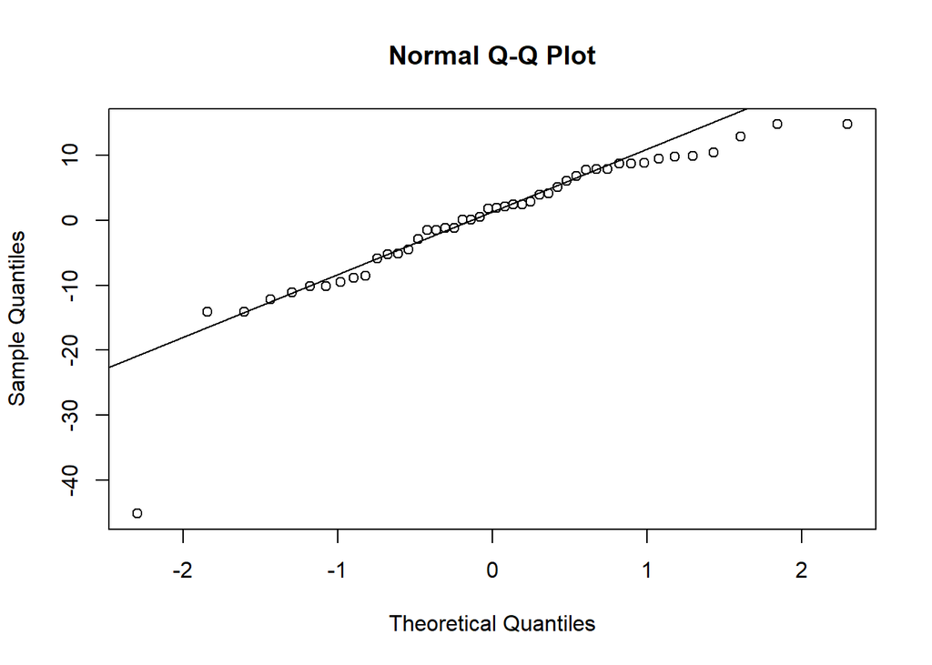

```r
qq1 <- qqnorm(av$residuals); qqline(av$residuals)
```

```r
cor.test(qq1$x,qq1$y)
```

```
##
##  Pearson's product-moment correlation
##
## data:  qq1$x and qq1$y
## t = 16.21, df = 44, p-value < 2.2e-16
## alternative hypothesis: true correlation is not equal to 0
## 95 percent confidence interval:
##  0.8685749 0.9583298
## sample estimates:
##       cor
## 0.9255097
```

```r
lillie.test(av$residuals)
```

```
##
##  Lilliefors (Kolmogorov-Smirnov) normality test
##
## data:  av$residuals
## D = 0.11663, p-value = 0.121
```

```r
shapiro.test(av$residuals)
```

```
##
##  Shapiro-Wilk normality test
##
## data:  av$residuals
## W = 0.86567, p-value = 8.066e-05
```

conducting a boxcox transformation in order to determine whether a transformation of the data would be appropriate.

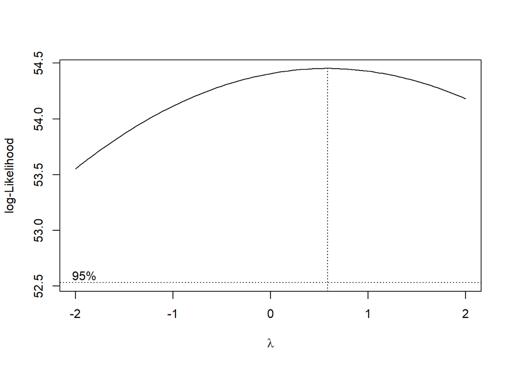

```r
bc=boxcox(trgdat$trg~trgdat$group)
boxcox(trgdat$trg~trgdat$group)
```

```r
lambda <- bc$x[which.max(bc$y)]
```

$\lambda$=0.5858586

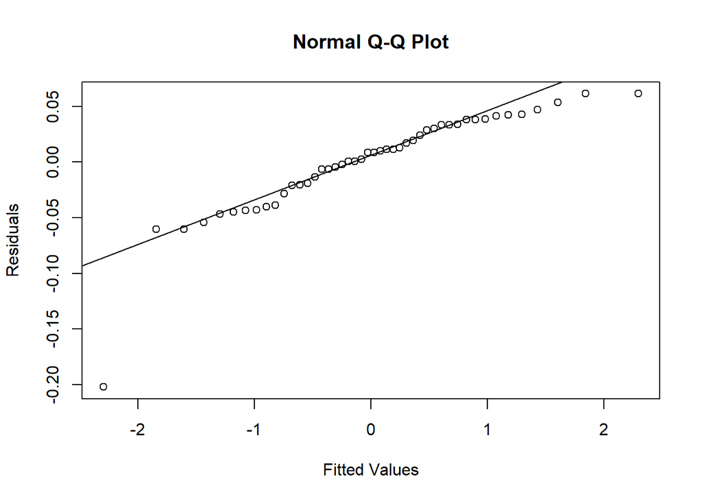

```r
fit <- aov(log(trgdat$trg)~trgdat$group)
qq <- qqnorm(fit$residuals,xlab="Fitted Values",ylab="Residuals")
qqnorm(fit$residuals,xlab="Fitted Values",ylab="Residuals"); qqline(fit$residuals)
```

```r
cor.test(qq$x,qq$y)
```

```
##
##  Pearson's product-moment correlation
##
## data:  qq$x and qq$y
## t = 15.259, df = 44, p-value < 2.2e-16
## alternative hypothesis: true correlation is not equal to 0
## 95 percent confidence interval:
##  0.8542199 0.9535345
## sample estimates:
##       cor
## 0.9170976
```

```r
lillie.test(fit$residuals)
```

```
##
##  Lilliefors (Kolmogorov-Smirnov) normality test
##
## data:  fit$residuals
## D = 0.11807, p-value = 0.1113
```

```r
shapiro.test(fit$residuals)
```

```
##
##  Shapiro-Wilk normality test
##
## data:  fit$residuals
## W = 0.85038, p-value = 3.144e-05
```

Looking at the qqplots of the original and transformed data, there does not appear to be an improvement in normality with the transformed data. Thus a transformation is not appropriate.

# Problem 2

## Part i)

Running an anova F test to determine if there is a difference between the trg mean of the control group and the trg mean of the combined treatment groups.

Assumptions:

Homogeneity of variance

Normality and independence of residual error

Linearity

$\mu_0$ = mean of control groups

$\mu_1$ = mean of combined treatment groups

$H_0: \mu_0=\mu_1$

$H_A: \mu_0 \neq \mu_1$

```r
trgdat2=trgdat%>%mutate(group2=factor(as.integer(group!="1")))
av2 <- aov(trgdat2$trg~trgdat2$group2)
kable(anova(av2))
```

|  | Df | Sum Sq | Mean Sq | F value | Pr(>F) |
| --- | --- | --- | --- | --- | --- |
| trgdat2$group2 | 1 | 3123.482 | 3123.4821 | 15.44571 | 0.0002965 |
| Residuals | 44 | 8897.822 | 202.2232 | NA | NA |

```r
qf(.95,1,44)
```

```
## [1] 4.061706
```

$\alpha=.05$

p-value = .0003

Critical Value for F-statistic with degrees of freedom 1,44 =4.0617

F test statistic: $F^*$ = MSR/MSE= 15.4457

$F^*>$ critical F value

$15.4457>4.0617$

Conclusion: Reject $H_0$ since p-value< .05 and test statistic is in the critical region.

Conclude that the control group and treatments groups have different a triglyceride mean.

## Part ii)

Running a Pearson correlation test to determine whether there is a linear relationship between group number and trg level.

We will look at the correlation between group and trg level.

Assumptions:

Homogeneity of variance

Normality and independence of residual error

Linearity

$H_0:$ Correlation = 0

$H_A:$ Correlation $\neq$ 0

```r
(cortest=cor.test(as.numeric(trgdat$group),trgdat$trg))
```

```
##
##  Pearson's product-moment correlation
##
## data:  as.numeric(trgdat$group) and trgdat$trg
## t = -7.9592, df = 44, p-value = 4.617e-10
## alternative hypothesis: true correlation is not equal to 0
## 95 percent confidence interval:
##  -0.8654842 -0.6150561
## sample estimates:
##        cor
## -0.7681935
```

p-value = 4.616961610^{-10}< .05

Conclusion: Reject $H_0$ since the p-value < $\alpha$. Conclude the true correlation is not equal to 0 thus there is a linear relationship between group and trg level.

A correlation of -.768 represents a negative linear relationship between group and trg level.

# Problem 3

```r
trgdat$dose=recode(trgdat$group,"1"=0,"2"=75,"3"=150,"4"=300,"5"=600)
trgdat3=trgdat %>% filter(dose!=0)
(model=lm(trgdat3$trg~trgdat3$dose))
```

```
##
## Call:
## lm(formula = trgdat3$trg ~ trgdat3$dose)
##
## Coefficients:
##  (Intercept)  trgdat3$dose
##    238.55423      -0.05058
```

```r
control=trgdat%>%filter(dose==0)
meancontrol=mean(control$trg)
```

Assumptions:

Linearity: $Y_i = \alpha+\beta X_i +\epsilon_i$

Xs are fixed constants

$\epsilon_i$ are independent and identially distributed $\sim N(0,\sigma^2)$

$\hat{Y_i}$=Predicted triglyceride level

$X_i$=dose (mg of peppermint extract)

$\hat{Y_i}=\hat{\alpha} +\hat{\beta} X_i$

$\hat{Y_i}=238.55423+-.05058X$

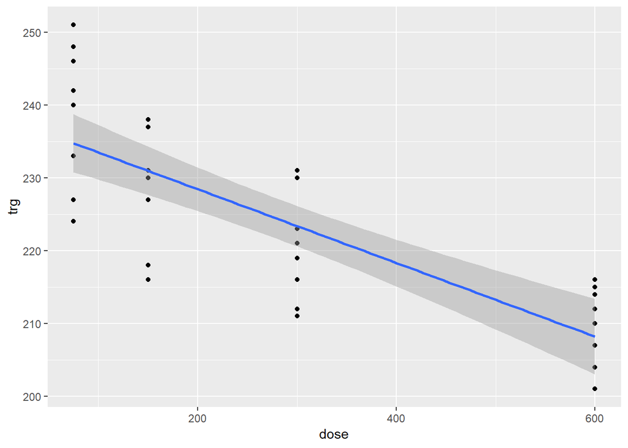

```r
ggplot(data = trgdat3,aes(x=dose,y=trg))+geom_point()+geom_smooth(method="lm")
```

```r
summary(model)
```

```
##
## Call:
## lm(formula = trgdat3$trg ~ trgdat3$dose)
##
## Residuals:
##      Min       1Q   Median       3Q      Max
## -14.9667  -5.0854  -0.3792   6.6646  16.2395
##
## Coefficients:
##                Estimate Std. Error t value Pr(>|t|)
## (Intercept)  238.554227   2.352245 101.416  < 2e-16 ***
## trgdat3$dose  -0.050584   0.006764  -7.478 1.12e-08 ***
## ---
## Signif. codes:  0 '***' 0.001 '**' 0.01 '*' 0.05 '.' 0.1 ' ' 1
##
## Residual standard error: 8.183 on 34 degrees of freedom
## Multiple R-squared:  0.6219, Adjusted R-squared:  0.6108
## F-statistic: 55.93 on 1 and 34 DF,  p-value: 1.117e-08
```

se=standard error=.00676

$\beta$=-.05058

95% confidence interval for slope:

(-.064<$\beta$<-.037)

Predicted mean triglyceride level for the control group:

$\hat{Y_0}=238.55423-.05058(0)$

$\hat{Y_0}=238.55423$

The observed trg mean of the control group was 244.2

Percent Error= $\dfrac{Observed-Predicted}{Predicted}*100$

$\dfrac{244.2-238.55423}{238.55423}*100=2.37\%$

Since the percent error is $2.37\%$ the predicted and sample mean values for the control group are reasonably similiar